# mtcars-assignement

Nick

Wednesday, September 23, 2015

### Context

You work for Motor Trend, a magazine about the automobile industry. Looking at a data set of a collection of cars, they are interested in exploring the relationship between a set of variables and miles per gallon (MPG) (outcome). They are particularly interested in the following two questions:

“Is an automatic or manual transmission better for MPG”

“Quantify the MPG difference between automatic and manual transmissions”

## Executive Summary

With the data we have at hand it appears that manual transmissions have a positive influence on mpg, in that they reduce the amount of fuels used.

It also appears that other variables may exert more influence over the response, with horse power and weight to definitely be considered.

## Detailed Analysis

First let’s just have a cursory look at the first few entries in our dataset:

```
##                    mpg cyl disp  hp drat    wt  qsec vs am gear carb
## Mazda RX4         21.0   6  160 110 3.90 2.620 16.46  0  1    4    4
## Mazda RX4 Wag     21.0   6  160 110 3.90 2.875 17.02  0  1    4    4
## Datsun 710        22.8   4  108  93 3.85 2.320 18.61  1  1    4    1
## Hornet 4 Drive    21.4   6  258 110 3.08 3.215 19.44  1  0    3    1
## Hornet Sportabout 18.7   8  360 175 3.15 3.440 17.02  0  0    3    2
## Valiant           18.1   6  225 105 2.76 3.460 20.22  1  0    3    1
```

Here we see some examples of the data and what we can expect to work with. There are a total of 11 variables and we also know there are a total of 32 observations.

An initial examination of the data shows that automatic and manual transmissions have a mean of 17.15 and 24.39 mpg respectively. We can also see the data is fairly sparse given the gaps in the distribution.

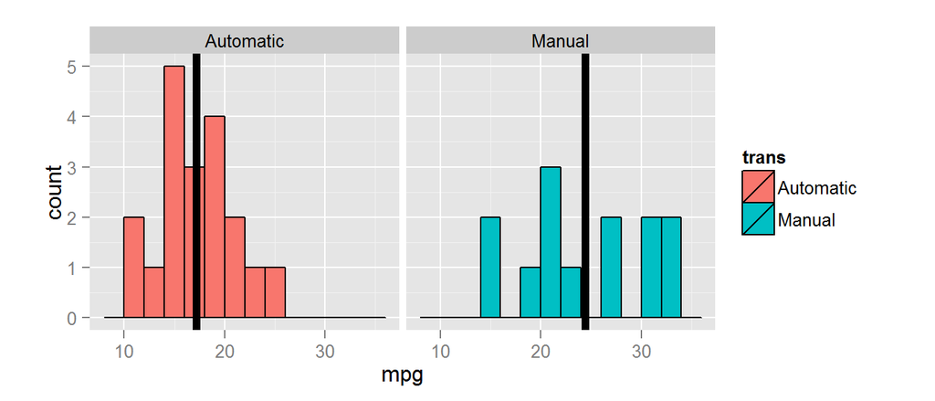

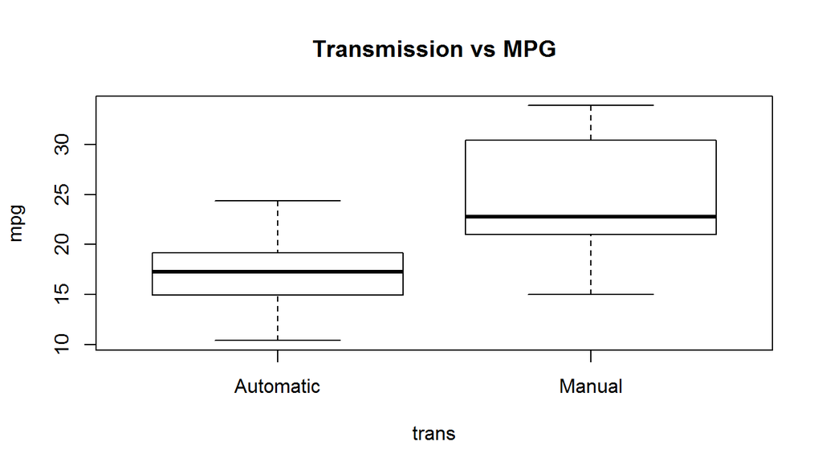

```r
plot(mpgVsTrans, main="Transmission vs MPG");
```

From the plot above we can see there is a definite trend to manual being more fuel efficient. So lets fit a linear model and examine the numbers.

```r
fit <- lm(mpg ~ am, data = mtcars);
summary(fit)$coeff
```

```
##              Estimate Std. Error   t value     Pr(>|t|)
## (Intercept) 17.147368   1.124603 15.247492 1.133983e-15
## am           7.244939   1.764422  4.106127 2.850207e-04
```

Concretely this shows an positive 7.25 improvement in the manual transmission over automatic.

If we consider the R^2 value, which is the will indicate how much the variable influences the response.

```r
summary(fit)$r.squared
```

```
## [1] 0.3597989
```

We see that transmission variable only accounts for around 36% variation in the model.

Let’s quickly examine some other variables and see their impact on the mpg prediction.

```r
fitWt <- lm(mpg ~ wt, data = mtcars);
fitHp <- lm(mpg ~ hp, data = mtcars);
```

## Conclusion

So although it appears that the transmission type does play a part in the mpg efficiency there are likely many other variable that will have a stronger influence. So require further consideration.

## Limitations of Study

There data itself has not mechanism to cross reference our data, many factors can play a role in the consumption of fuel. Different tire brands, the fuel octane, driver or rolling road used. This information is not captured.

Ultimately comparing only mpg vs transmission type is likely a trivialisation of the data resulting in *underfitting* we’re omitting necessary covariates resulting in *bias*. Unfortunately with the data at hand fitting more covariates results in large variance thus a less useful model.

The ideal way to conduct the study would be to have makes and models of cars that have both a manual and automatic variant to pair like with like. Then with all other variables being even we could answer with a higher degree of certainty.

## Supporting Figures

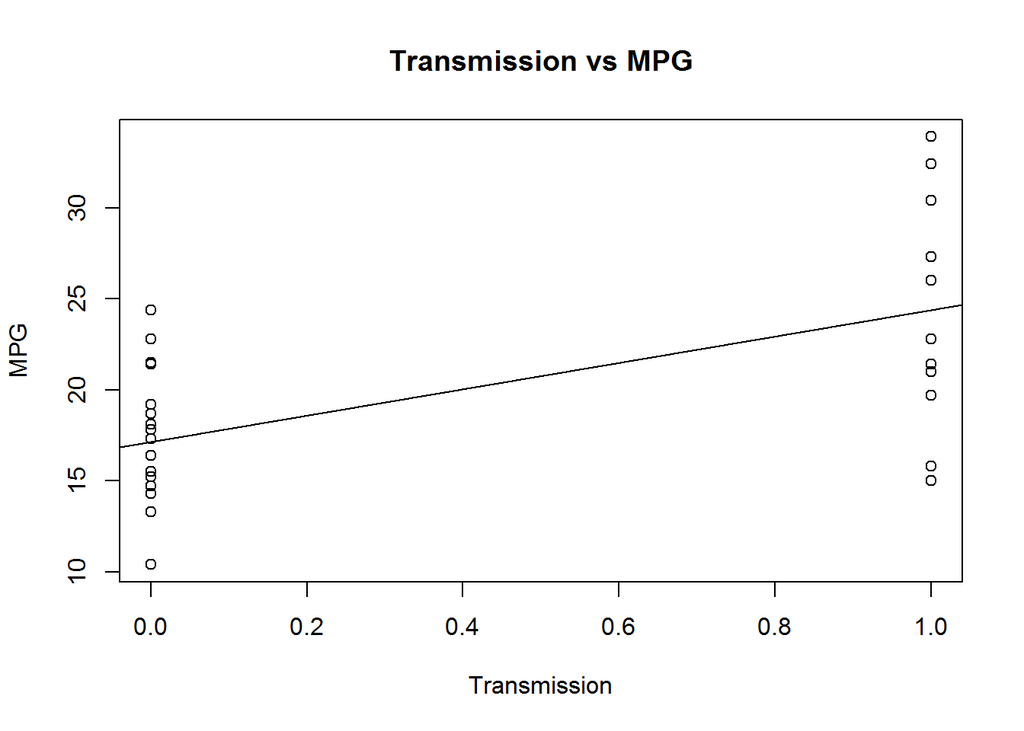

```r
plot(mtcars$am, mtcars$mpg, xlab="Transmission", ylab="MPG", main="Transmission vs MPG")
abline(fit)
```

[figure not shown]

```r
plot(mtcars$wt, mtcars$mpg, xlab="Weight", ylab="MPG", main="Transmission vs Weight")
abline(fitWt)
```

[figure not shown]

```r
plot(mtcars$hp, mtcars$mpg, xlab="HP", ylab="MPG", main="Transmission vs HP")
abline(fitHp)
```